# Analysis of NBA 2023-2024 Regular Season: Predicting Winning Percentages for 2024-2025

Tyler Bush, Konchok Shonu, Joshua Sherry

#### Introduction

The goal of this project is to thoroughly explain the data science pipeline and what to learn from it. In this tutorial, we explore the entire data science pipeline through the lens of the evergrowing field of sports analytics, specifically analyzing the 2023-2024 NBA (National Basketball Association) regular season. Our goal is to use data from the past season and machine learning (ML) techniques to predict the winning percentage of each team for the upcoming 2024-2025 season.

These predictions provide a lot of value for both fans of the teams and the teams themselves. Team predictions are used to aid the teams to plan for what moves to make in the offseason and how to plan for the year overall. It is used not only to measure a team's success, but to additionally measure the impact and interest the team can draw from fans. Ultimately, understanding and projecting team trajectories helps to shape the narrative of the league, providing a roadmap for both short-term dynamics and long-term developments in the NBA.

Additionally with the recent explosion of sports gambling, the value of team predictions and their ability to perform has increased exponentially.

#### The steps we will follow include:

- Data Collection
- Data Processing
- Exploratory Analysis & Data Visualization
- Model: Analysis, Hypothesis Testing, & ML
- Interpretation: Insight & Policy Decision

Each season there are countless projects and analysis done attempting to predict all aspects of the NBA season, including awards, the champion, and each team's performance. Our analysis looks to apply our own machine learning technqiues and unique data from this season to perform analysis on team success. [This](https://www.stat.berkeley.edu/~aldous/Research/Ugrad/Stanley_Yang%20_Thesis.pdf) is a good example from a past season done by the Statistics department at the University of California at Berkeley: .

This project handles a variety of team data gathered as a cummulative result of the 2023-2024 NBA season. The data includes standings, offensive and defensive performance, and overall efficiency. An NBA team's success can be subjective, but we will be calculating projected win percentage (out of the usual 82 game season), and how each team would compare in the end of year standings.

It is important to note that many teams will add, remove, and trade players during the NBA offseason during the summer. This analysis is used with the rosters NBA teams have currently, but many teams might have significant roster changes by the start of next season that can impact their predicted performance. This analysis is given the rosters that each team has currenlty, which can be used by teams and fans to understand what moves the team should make. Throughout this tutorial we find many strengths and weaknesses that NBA teams could focus on improving on, as well as other statistics that could demonstrate what moves the team should make to improve their predicted win percentage for the upcoming 2024-2025 NBA season.

# Data Collection

The initial step in the data science pipeline we need to find relevant datasets that are related to our topic, and load and convert the data into a dataframe we could perform analysis on. A famous website that is home to a significant amount of NBA data is [Basketball Reference](https://www.basketball-reference.com/).

Connecting to official NBA endpoints, we download each teams' end of season data. This includes their record, performance, overall field goal percentage (what percent of the shots they took were made), and their respective ranking for each standard category in league overall.

In order to match each team's data to the team, we must load each team into a dataframe as well, and add the respective data to the matching NBA team.

Specfically to collect data we use APIs like nba_api and datasets from Basketball Reference. Additional Features: Include advanced metrics like player efficiency ratings, win shares, etc., from databases like NBA Advanced Stats.

### Imports

```python
import pandas as pd
from nba_api.stats.static import teams
from nba_api.stats.endpoints import leaguedashteamstats

#Used later
from sklearn.preprocessing import StandardScaler
from sklearn.linear_model import LinearRegression
from sklearn.metrics import r2_score
from sklearn.decomposition import PCA
from sklearn.model_selection import train_test_split
from sklearn.ensemble import RandomForestRegressor
from sklearn.svm import SVR
from sklearn.metrics import mean_squared_error, mean_absolute_error
from scipy.stats import ttest_ind
import seaborn as sns
import matplotlib.pyplot as plt
import numpy as np
```

The first main library that we use through the entirety of the project is [Pandas](https://pypi.org/project/pandas/). Pandas is a popular open source Python package that is built on top of Python for ease of use. It allows us to store the data in a dataframe and perform manipulations easily and efficienlty.

In addition to Pandas, we will use nba_api, an official api client package that will allow us to import the teams and their stats, and easily place them in a pandas dataframe for manipulation and analysis.

### Storing the Data

```python
#Load into Dataframe

# Fetch all NBA teams
nba_teams = teams.get_teams()

# Select the season to analyze (we are using the most recent season)
season = '2023-24'

# Get the team stats for the 2023-24 season
team_stats_provider = leaguedashteamstats.LeagueDashTeamStats(season=season)

#apply the stats loaded from npa_api into a new dataframe team_stats_df
team_stats_df = team_stats_provider.get_data_frames()[0]

# Display the first few rows of the dataframe, show all the categories loaded
team_stats_df.head()
```

|  | TEAM_ID | TEAM_NAME | GP | W | L | W_PCT | MIN | FGM | FGA | FG_PCT | ... | REB_RANK | AST_RANK | TOV_RANK | STL_RANK | BLK_RANK | BLKA_RANK | PF_RANK | PFD_RANK | PTS_RANK | PLUS_MINUS_RANK |
| --- | --- | --- | --- | --- | --- | --- | --- | --- | --- | --- | --- | --- | --- | --- | --- | --- | --- | --- | --- | --- | --- |
| 0 | 1610612737 | Atlanta Hawks | 82 | 36 | 46 | 0.439 | 3971.0 | 3529 | 7584 | 0.465 | ... | 6 | 16 | 16 | 16 | 26 | 22 | 15 | 7 | 5 | 21 |
| 1 | 1610612738 | Boston Celtics | 82 | 64 | 18 | 0.780 | 3966.0 | 3601 | 7396 | 0.487 | ... | 2 | 14 | 1 | 27 | 1 | 1 | 2 | 30 | 2 | 1 |
| 2 | 1610612751 | Brooklyn Nets | 82 | 32 | 50 | 0.390 | 3961.0 | 3334 | 7307 | 0.456 | ... | 11 | 20 | 12 | 28 | 12 | 16 | 13 | 21 | 25 | 22 |
| 3 | 1610612766 | Charlotte Hornets | 82 | 21 | 61 | 0.256 | 3946.0 | 3281 | 7133 | 0.460 | ... | 30 | 26 | 18 | 25 | 25 | 13 | 7 | 29 | 28 | 30 |
| 4 | 1610612741 | Chicago Bulls | 82 | 39 | 43 | 0.476 | 3996.0 | 3448 | 7339 | 0.470 | ... | 14 | 23 | 3 | 9 | 18 | 14 | 17 | 14 | 22 | 20 |

5 rows × 54 columns

For this project, ensure the data is stored in a structured format, in this case we will use a pandas dataframe due to the large amount of data being loaded.

# Data Processing

### Cleaning and Preprocessing

Data from sports statistics often includes missing values, irrelevant features, and needs to be normalized. Here's how we handle these issues:

- Missing Values: Fill or drop missing values. Luckily there are no missing values.
- Normalization: Standardize the scale for numerical features to improve ML performance. We want our data to be in a normal curve in comparison to other teams.
- Feature Selection: We are including important features that correlate to win-loss: 'Win Percentage', 'Field Goal Attempts', '3-Point Field Goal Attempts', 'Free Throw Attempts', 'Rebounds', 'Assists', 'Turnovers', 'Steals', 'Blocks', and 'Points Per Game.' These statistics are the backbone for a teams success and their collective performance will evaluate their perfomance accross all aspects of the game. All major advanced statistics including [Offensive Rating (OFFRTG)](https://en.wikipedia.org/wiki/Offensive_rating#:~:text=Offensive%20proficiency%20rating%20or%20offensive,author%20and%20statistician%20Dean%20Oliver.), [Rebound Rate (REB%, OREB%, DREB%)](https://en.wikipedia.org/wiki/Rebound_rate), Player Impact Estime (PIE, this can be cummulative to calculate a team's impact), etc. are calculating using these given backbone statistics.
- For a greater understanding of a team's efficiency, we calculate the statistics [Offensive Efficiency (OFF-EFF)](https://www.nbastuffer.com/analytics101/offensive-efficiency/) (One teams offensive efficiency is the other team's defensive efficiency), [Defensive Efficiency (DEF-EFF)](https://www.nbastuffer.com/analytics101/defensive-efficiency/), Assist to Turnover Ratio (AST-TO%, the best substitute for Turnover Ratio due to simplicity with the normal curve), and Three Point Rate (3PR), which is not an advanced statistic but we knew it's addition is a necessity for efficiency as the 3 point shot is the most valuable and [determines a team's winningness more than any other shot](https://wsb.wharton.upenn.edu/wp-content/uploads/2023/05/Kostacos_2023_Basketball_HS.pdf).

[Here](https://www.nba.com/stats/help/faq) is some unique information on how these stats correlate with wins, and the specific importance of the four advanced stats [Effective Field Goal Percentage (eFG%)](https://en.wikipedia.org/wiki/Effective_field_goal_percentage), [Turnover Ratio (TO%)](https://www.nbastuffer.com/analytics101/turnover-ratio/), Offensive Rebound Percentage (see above), and [Free Throw Rate (FTR/FTA%)](https://ilevy.wordpress.com/stats-glossary/ftr/#:~:text=Free%20Throw%20Rate%20is%20calculated,The%20formula%20is%20FTA%2FFGA.) and how they correlate highest with a team's win percentage. Due to the high correlation these statistics have shown to winning percentage, we made sure to calculate them or close substitutes (AST-TO% rather than TO% and 3PR rather than eFG%).

We will be using these 4 statistics later on.

```python
# Feature selection
# Exact stats separated specified above
relevant_features = ['TEAM_ID', 'W_PCT', 'FGA', 'FG3A', 'FTA', 'REB', 'AST', 'TOV', 'STL', 'BLK', 'PTS']
processed_df = team_stats_df[relevant_features].copy()  # Create a copy to avoid modifying the original DataFrame

# We now have the exact data we want individualized, we have the year specified,
# the specific statistics required, and all null values (there are none) removed.

# Normalize the data, use StandardScaler from sklearn
scaler = StandardScaler()

#Convert the columns to float64 before scaling
processed_df[relevant_features[1:]] = processed_df[relevant_features[1:]].astype('float64')

# the function fit_transform fits the data into a model we can scale, for normalization
processed_df.loc[:, relevant_features[1:]] = scaler.fit_transform(processed_df.loc[:, relevant_features[1:]])

# Create new features like offensive efficiency, defensive efficiency, AST/TO and 3PR
processed_df['OFF_EFF'] = processed_df['PTS'] / processed_df['FGA']
processed_df['DEF_EFF'] = processed_df['REB'] + processed_df['BLK'] + processed_df['STL']
processed_df['AST_TOV_RATIO'] = processed_df['AST'] / processed_df['TOV']
processed_df['THREE_POINT_RATE'] = processed_df['FG3A'] / processed_df['FGA']

processed_df.head()
```

|  | TEAM_ID | W_PCT | FGA | FG3A | FTA | REB | AST | TOV | STL | BLK | PTS | OFF_EFF | DEF_EFF | AST_TOV_RATIO | THREE_POINT_RATE |
| --- | --- | --- | --- | --- | --- | --- | --- | --- | --- | --- | --- | --- | --- | --- | --- |
| 0 | 1610612737 | -0.379350 | 1.766641 | 0.920415 | 1.030936 | 0.788985 | -0.047265 | -0.065989 | 0.047050 | -0.828731 | 0.984404 | 0.557218 | 0.007304 | 0.716268 | 0.520997 |
| 1 | 1610612738 | 1.741279 | 0.636824 | 2.601735 | -1.047431 | 1.947754 | 0.133324 | -1.609648 | -1.252420 | 1.833922 | 1.520822 | 2.388134 | 2.529256 | -0.082828 | 4.085484 |
| 2 | 1610612751 | -0.684074 | 0.101964 | 0.566907 | -0.577324 | 0.362967 | -0.568969 | -0.466633 | -1.274825 | 0.037813 | -0.919295 | -9.015882 | -0.874045 | 1.219308 | 5.559871 |
| 3 | 1610612766 | -1.517400 | -0.943718 | -0.390152 | -2.218574 | -2.278343 | -1.030477 | 0.157901 | -1.140397 | -0.797221 | -1.823042 | 1.931766 | -4.215961 | -6.526091 | 0.413421 |
| 4 | 1610612741 | -0.149252 | 0.294273 | -1.071303 | -0.412374 | 0.192560 | -0.930149 | -1.315057 | 0.562357 | -0.434848 | -0.464507 | -1.578487 | 0.320069 | 0.707307 | -3.640503 |

# Exploratory Analysis & Data Visualization

### Visualizing the Data

In this section of the data science life cycle, we are going to plot the data to gain a better understanding and find any trends. Also, we attempt to perform statistical analyses in this section to gain mathematical evidence for the trends we may discover. In other words, as the title is indicating, we are going to further explore the data.

Our goal is to find what statistics make a team win and how much, and other relationships between a team's overall statistics. To start we will look at the trend for a team's win percentage.

All data is now normalized, so their values are in relation to standard deviations on a [normal curve](https://en.wikipedia.org/wiki/Normal_distribution). Their demonstrated value is given in standard deviations from the mean, or average. The farther in one direction, the more distant it is from the average.

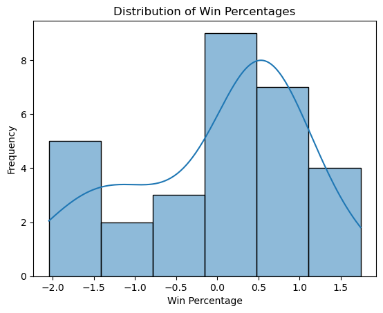

```python
# We will no use seaborn and matplotlib packages, and PCA from sklearn
# Win Percentage Normal Distribution Histogram with drawn curve
sns.histplot(processed_df['W_PCT'], kde=True)
plt.title('Distribution of Win Percentages')
plt.xlabel('Win Percentage')
plt.ylabel('Frequency')
plt.show()
```

This histogram with a KDE (Kernel Density Estimate) plot shows the normal distribution of win percentages among NBA teams.

- The distribution appears approximately normal with a slight skew to the left. This means the mean is noticeably less than the median. When this occurs, most teams have a win percentage above the calculated average, where fewer yet larger negative outliers balance them out.
  - This is explained by the idea of tanking), where the worst teams in the league will compete for the worst record to have a higher draft placement.
- Most teams have a win percentage around 0 to 1.0, indicating a balanced league where many teams have an average to above-average win rate, since most teams are trying to win, and a much fewer teams may be trying to lose.
- There are fewer teams with very low or very high win percentages, suggesting a competitive league with few extreme outliers.
- Given this information, we can conclude a normal curve is reliable to plot and demonstrate team win percentage.

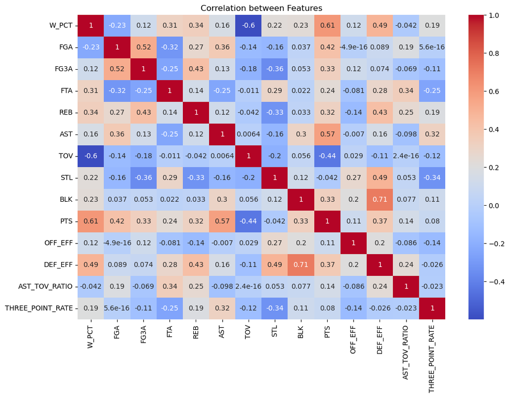

```python
# Correlation Heatmap between each of the used statistics

# Use the .corr() function in pandas that computes the pairwise correlation between two columns
# Remove Team_ID as it is not a statistic but an identifier
correlation_matrix = processed_df.drop('TEAM_ID', axis = 1).corr()
plt.figure(figsize=(12, 8))

#Use a heatmap to use color to demonstrate correlation
sns.heatmap(correlation_matrix, annot=True, cmap='coolwarm')
plt.title('Correlation between Features')
plt.show()
```

This heatmap displays the correlation coefficients between each of the taken team statistics.

- **Key Correlations**:
  - **Positive Correlations**:
    - `W_PCT` (Win Percentage) is positively correlated with `PTS` (Points), `OFF_EFF` (Offensive Efficiency), and `DEF_EFF` (Defensive Efficiency), suggesting that scoring and overall efficiency are crucial to winning. This goes along with what we have found earlier.
    - `AST` (Assists) is positively correlated with `PTS`, indicating that teams that pass the ball well tend to score more points. This is a given though, as more assists quite literally mean more points scored.
  - **Negative Correlations**:
    - `W_PCT` and `PTS` has a negative correlation with `TOV` (Turnovers), implying that teams with fewer turnovers tend to win more games. This also agrees what we have found.
    - An interesting find is that both `3PA` (3 Pointers Attempted) and `3PR` (3 Pointer Percentage) are more negatively correlated with `STLS`. This is a new finding, but the idea of a [fastbreak offense](https://en.wikipedia.org/wiki/Fast_break#:~:text=Fast%20break%20is%20an%20offensive,have%20time%20to%20set%20up.) explains this phenomena. When a team gets a steal, they will try to score as quickly as possible before the other team is set on defense, and these baskets consist of easier to make shots when the players are open, which would make there less 3 pointers attempted.
- **Neutral/Low Correlations**:
  - Some features like `STL` (Steals) and `BLK` (Blocks) show low or mixed correlations with other stats, suggesting that these might be less critical in isolation to each other. How many steals one team gets does not correlate to how many blocks they get, and these statistics are more independent.

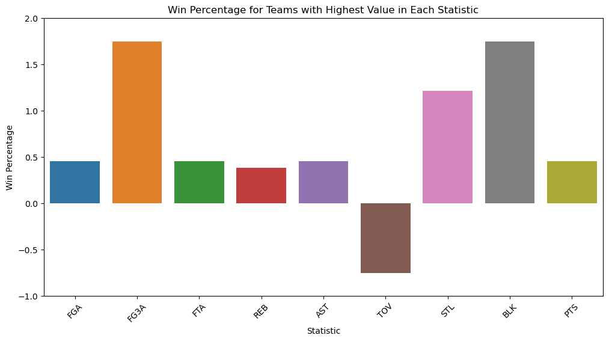

```python
stat_max_teams = {}
for stat in relevant_features[2:]:  # Exclude TEAM_ID and W_PCT
    max_team_id = processed_df.loc[processed_df[stat].idxmax(), 'TEAM_ID']
    stat_max_teams[stat] = max_team_id

# Extract win percentages for these teams
win_percentages = {}
for stat, team_id in stat_max_teams.items():
    win_pct = processed_df.loc[processed_df['TEAM_ID'] == team_id, 'W_PCT'].values[0]
    win_percentages[stat] = win_pct

# Convert to DataFrame for plotting
win_pct_df = pd.DataFrame(list(win_percentages.items()), columns=['Statistic', 'Win Percentage'])

# Plot the win percentages
plt.figure(figsize=(12, 6))
sns.barplot(data=win_pct_df, x='Statistic', y='Win Percentage')
plt.title('Win Percentage for Teams with Highest Value in Each Statistic')
plt.xlabel('Statistic')
plt.ylabel('Win Percentage')
plt.xticks(rotation=45)
plt.ylim(-1, 2)  # Assuming Win Percentage is between 0 and 1
plt.show()
```

This bar graph shows how the `W_PCT` (standardized on a normal curve) of the team with the highest value in each of the saved statistics. Of course this is a small sample of 1 team, but it can show what high values of each of the statistics can do for a team.

- **Positve Values:**
  - The team with the most `FG3A` or 3 pointers taken and the most blocks are the Boston Celtics, who had the best win rate in the league by a good margin, almost 2 standard deviations above the average.
  - The team with the most `STLS` was The Oklahoma City Thunder, who had the second best record in the league and a noticeably high win rate as well.
  - Although all with above average records, the teams with the most `FGA`, `FTA`, `REB`, `AST`, and `PTS` did not have a significantly high win rate, as they are all with 1 standard deviation of the average.
- **Negative Values:**
  - The team with the most `TOV` are the Utah Jazz, who had the 8th worst record in the league. It is more clear hear that the team with the most turnovers lost a lot more.

Overall, off of an insignificant 1 team sample size, we can see that the teams that get the most `FG3A` and `STLS` win the most, and the teams with the most `TOV` lose the most.

For 3 pointers attempted, it has [been found recently](https://www.goldenstateofmind.com/2019/12/1/20990988/do-more-3s-mean-more-wins-what-do-the-numbers-say-what-do-you-say-poll#:~:text=For%20an%20attempted%203%2Dpoint,times%203P%25%20times%203%20points.) that teams who shoot more 3s win a lot more because they shoot more 3s because they make them at a higher rate. Which makes sense, teams who shoot better from 3 will take more 3s as a result.

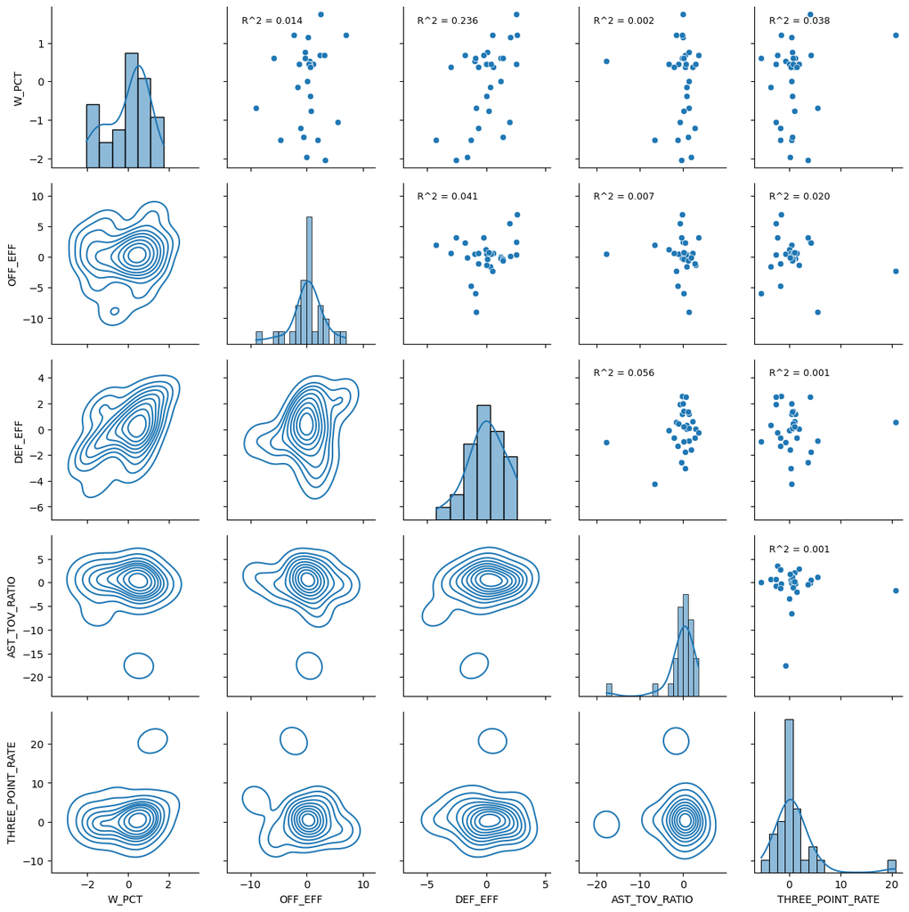

```python
# Initialize PCA and fit_transform to reduce dimensions
pca = PCA(n_components=2)  # reduce to 2 components for visualization purposes
principalComponents = pca.fit_transform(processed_df[relevant_features[1:]])

# Create a DataFrame with principal components
principalDf = pd.DataFrame(data=principalComponents, columns=['Principal Component 1', 'Principal Component 2'])

# Function to calculate R-squared
def calculate_r_squared(x, y):
    model = LinearRegression()
    x = x.values.reshape(-1, 1)
    model.fit(x, y)
    y_pred = model.predict(x)
    return r2_score(y, y_pred)

# Create the pairplot with R-squared annotations
g = sns.PairGrid(processed_df, vars=['W_PCT', 'OFF_EFF', 'DEF_EFF', 'AST_TOV_RATIO', 'THREE_POINT_RATE'])
g.map_upper(sns.scatterplot)
g.map_lower(sns.kdeplot)
g.map_diag(sns.histplot, kde=True)

# Annotate R-squared values on the scatter plots
variables = ['W_PCT', 'OFF_EFF', 'DEF_EFF', 'AST_TOV_RATIO', 'THREE_POINT_RATE']
for i, var1 in enumerate(variables):
    for j, var2 in enumerate(variables):
        if i < j:
            x = processed_df[var2]
            y = processed_df[var1]

            #use the calculate_r_squared function from above
            r2 = calculate_r_squared(x, y)

            ax = g.axes[i, j]

            #annotate each given graph with its corresponding r^2 function
            ax.annotate(f"R^2 = {r2:.3f}", xy=(0.1, 0.9), xycoords='axes fraction', fontsize=9, color='black')

plt.show()
```

This pairplot shows scatter plots and histograms for selected features: `W_PCT`, `OFF_EFF`, `DEF_EFF`, `AST_TOV_RATIO`, and `THREE_POINT_RATE`. We calculated these values earlier and explained their importance, as they are the 4 statistics that have been found to [best predict win rate](https://www.nba.com/stats/help/faq) historically.

This helps confirm our belief that these statistics help predict a team's win percentage.

But, the calculated r^2 values for all of these still come up as insignificant, as we have already discussed how obviously one statistic alone cannot determine a team's win rate.

Overall our performed explanatory analysis has found some significant postive correlations and has agreed with our given hypotheses. We will now use what we found in a machine learning model.

# Model: Analysis, Hypothesis Testing, & Machine Learning

### Building the Model

We will use the concept of linear regression to predict the win percentage. Additionally, we explore more complex models like Random Forest and SVM to see if they provide better predictions.

[Linear Regression](https://en.wikipedia.org/wiki/Linear_regression) is a statistical method used to model the relationship between a dependent variable and one or more independent variables by fitting a linear equation to observed data. The goal is to predict the dependent variable based on the values of the independent variables, minimizing the difference between the observed and predicted values.

- In our example, we will predict our dependent variable `W_PCT` given the other variables we have analyzed as our independent variables.

[Random Forest](https://www.ibm.com/topics/random-forest#:~:text=Random%20forest%20is%20a%20commonly,Decision%20trees) is an ensemble learning method that constructs many (we use 100) [decision trees](https://en.wikipedia.org/wiki/Decision_tree#:~:text=A%20decision%20tree%20is%20a,only%20contains%20conditional%20control%20statements.) (models chance outcomes) during training and outputs the mean prediction of the individual trees for our performed regression, giving a more robust predictive model. It mitigates overfitting by randomly selecting subsets of features and data points for each tree, promoting generalization and robustness, which is also extremely useful for us.

Support Vector Machine (SVM) for regression that works by finding the hyperplane that best separates data points into different classes while maximizing the margin between them, making it robust to outliers and effective in high-dimensional spaces.

- With our discovery of outliers earlier, this will be especially useful. Again we will be looking into each of the analyzed statistics and performing regression on them against `W_PCT`.

Two find the accuracy of these models, we will calculate their r^2, MSE, and MAE.

### Hypothesis Testing

Hypothesis testing is a statistics method used to evaluate whether observed data deviates significantly from what is expected under a predicted null hypothesis. It involves using sample data to determine if there is enough evidence to reject the null hypothesis in favor of the alternative.

- We will be using [the t-test](https://en.wikipedia.org/wiki/Student%27s_t-test) as we only have sample means, to compare the difference between high scoring and low scoring teams.

```python
# Splitting the data into training and testing sets

# Our independent variables are all observed and analyzed stats from before
X = processed_df.drop('W_PCT', axis=1)

# Our independent and predicted variable is `W_PCT`
y = processed_df['W_PCT']
X_train, X_test, y_train, y_test = train_test_split(X, y, test_size=0.2, random_state=42)

# Data Preprocessing
# Use the StandardScaler from sklearn
scaler = StandardScaler()
X_train_scaled = scaler.fit_transform(X_train)
X_test_scaled = scaler.transform(X_test)

# Linear Regression (First)
lr_model = LinearRegression()
# Use sklearn's LinearRegression() method to perform

lr_model.fit(X_train_scaled, y_train)

# Make predictions
y_pred_lr = lr_model.predict(X_test_scaled)

# Calculate r^2, MSE and MAE
lr_r2 = r2_score(y_test, y_pred_lr)
lr_mse = mean_squared_error(y_test, y_pred_lr)
lr_mae = mean_absolute_error(y_test, y_pred_lr)
print("Linear Regression R^2:", lr_r2)
print("Linear Regression MSE:", lr_mse)
print("Linear Regression MAE:", lr_mae)

# Random Forest
rf_model = RandomForestRegressor(n_estimators=100)
# Use sklearn's RandomForestRegressor() method to perform, we specified 100 decision trees

rf_model.fit(X_train, y_train)

# Make predictions
y_pred_rf = rf_model.predict(X_test)

# Calculate r^2, MSE and MAE
rf_r2 = r2_score(y_test, y_pred_rf)
rf_mse = mean_squared_error(y_test, y_pred_rf)
rf_mae = mean_absolute_error(y_test, y_pred_rf)
print("Random Forest R^2:", rf_r2)
print("Random Forest MSE:", rf_mse)
print("Random Forest MAE:", rf_mae)

# Support Vector Regression
svm_model = SVR()
# Use sklearn's SVR() method to perform it will do SVM specifically for regression

svm_model.fit(X_train_scaled, y_train)

# Calcualte predictions
y_pred_svm = svm_model.predict(X_test_scaled)

# Calculate r^2, MSE and MAE
svm_r2 = r2_score(y_test, y_pred_svm)
svm_mse = mean_squared_error(y_test, y_pred_svm)
svm_mae = mean_absolute_error(y_test, y_pred_svm)
print("SVM R^2:", svm_r2)
print("SVM MSE:", svm_mse)
print("SVM MAE:", svm_mae)

# Feature Importance using Random Forest Model (easier to use with Random Forest)
feature_importances = pd.DataFrame({'Feature': X.columns, 'Importance': rf_model.feature_importances_})
feature_importances = feature_importances.sort_values(by='Importance', ascending=False)
print("Feature Importance:")
print(feature_importances)
```

```
Linear Regression R^2: 0.8443689804230221
Linear Regression MSE: 0.1949729710092002
Linear Regression MAE: 0.3586312081246503
Random Forest R^2: 0.26454995562377537
Random Forest MSE: 0.9213643949042946
Random Forest MAE: 0.9018893250529733
SVM R^2: 0.5552728237544537
SVM MSE: 0.5571497191036402
SVM MAE: 0.634473712057649
Feature Importance:
             Feature  Importance
6                TOV    0.408461
9                PTS    0.193479
3                FTA    0.087034
11           DEF_EFF    0.075366
4                REB    0.042231
8                BLK    0.035289
1                FGA    0.033254
12     AST_TOV_RATIO    0.029188
2               FG3A    0.025061
10           OFF_EFF    0.021078
7                STL    0.018770
5                AST    0.016980
13  THREE_POINT_RATE    0.013810
0            TEAM_ID    0.000000
```

### Linear Regression:

- R-squared (R^2): Achieved a high R-squared value of 0.844, indicating that approximately 84.4% of the variance in the win percentage is explained by the model.
  - Error Metrics:
    - Mean Squared Error (MSE): 0.195
    - Mean Absolute Error (MAE): 0.359 Overall this was by far the best model, which actually made a [statistically significant and strong](https://www.researchgate.net/post/what_is_the_acceptable_r-squared_value#:~:text=In%20many%20scientific%20disciplines%2C%20an,variables%20in%20the%20regression%20model.) r^2 value above 0.8. This model gave us incredible results for predicting win percentage and the error values are rather insignificant compared to the variance.

**We believe this model would be great for predicting the win percentages for next year.**

## Analysis and Hypothesis Testing

- Our Null Hypothesis, or prediciton, is that high schoring teams and low scoring teams have equal win percentages.
- Our Alternative Hypothesis is that the win rates of these two groups are not equal.
- We will use an alpha value of 0.01, meaning a p-value below this will have us reject our null hypothesis

Our goal is to reject our null hypothesis, as we have discussed how scoring more leads to more wins.

```python
# High-scoring vs. Low-scoring teams

# Sort the teams in half in comparison to median, not mean, as there were significant outliers shown before
high_scoring = processed_df[processed_df['PTS'] > processed_df['PTS'].median()]
low_scoring = processed_df[processed_df['PTS'] <= processed_df['PTS'].median()]

# Perform the t-test, and print out our p-value, the lower the least likely our null hypothesis is true
t_stat, p_val = ttest_ind(high_scoring['W_PCT'], low_scoring['W_PCT'])
print("T-test between high and low scoring teams: T-stat = {}, P-value = {}".format(t_stat, p_val))
```

```
T-test between high and low scoring teams: T-stat = 3.589297500316128, P-value = 0.0012487870804214578
```

The T-statistic value of 3.589 indicates that the difference in mean win percentages between high-scoring and low-scoring teams is 3.589 standard deviations away from the mean difference expected under the null hypothesis. Since the p-value is less than the significance level selected (alpha = 0.01), we have sufficient evidence to conclude that this difference is unlikely to be due to random chance.

Therefore, we accept the alternative hypothesis, suggesting that the win rates of high-scoring teams and low-scoring teams are indeed not equal. This implies that scoring performance has a significant impact on team success in the NBA, with high-scoring teams generally achieving higher win percentages compared to low-scoring teams.

Thus our previous ideas of greater scoring leading to a higher win percentage is deemed statistically significant.

## Model: Analysis, Hypothesis Testing, & ML

### Predicting Future Performance

With the models trained, we will use them to predict the 2024-2025 winning percentage for each of the teams. We'll assume the feature set for the 2024-2025 season can be simulated or estimated based on historical trends and player movements.

For this tutorial, we'll simulate the 2024-2025 season data by adjusting the 2023-2024 data with [random noise](https://en.wikipedia.org/wiki/Noisy_data#:~:text=Random%20noise%20is%20often%20a,noise%20is%20an%20unavoidable%20problem.) to reflect changes like player improvement, trades, and other factors. We previously discussed how many teams will change their rosters by next season, and this accounts for that.

```python
import numpy as np

# Simulate next season's features by introducing random noise
np.random.seed(42)
noise = np.random.normal(0, 0.1, X.shape)
future_X = X + noise

# Display the first few rows of the future data
future_X.head()
```

|  | TEAM_ID | FGA | FG3A | FTA | REB | AST | TOV | STL | BLK | PTS | OFF_EFF | DEF_EFF | AST_TOV_RATIO | THREE_POINT_RATE |
| --- | --- | --- | --- | --- | --- | --- | --- | --- | --- | --- | --- | --- | --- | --- |
| 0 | 1.610613e+09 | 1.752815 | 0.985184 | 1.183239 | 0.765570 | -0.070679 | 0.091933 | 0.123793 | -0.875679 | 1.038660 | 0.510876 | -0.039269 | 0.740465 | 0.329669 |
| 1 | 1.610613e+09 | 0.580595 | 2.500452 | -1.016006 | 1.856951 | -0.007906 | -1.463083 | -1.274998 | 1.840675 | 1.378347 | 2.333696 | 2.540348 | -0.197928 | 4.123054 |
| 2 | 1.610613e+09 | 0.072795 | 0.506736 | -0.392096 | 0.361617 | -0.674741 | -0.384379 | -1.396909 | 0.058699 | -1.115262 | -9.148701 | -0.854359 | 1.293155 | 5.577008 |
| 3 | 1.610613e+09 | -0.973828 | -0.538005 | -2.290558 | -2.324407 | -0.924765 | 0.192263 | -1.316701 | -0.764812 | -1.861551 | 1.864074 | -4.154793 | -6.422992 | 0.506549 |
| 4 | 1.610613e+09 | 0.263352 | -1.038176 | -0.314820 | 0.144643 | -0.948715 | -1.425690 | 0.442736 | -0.353595 | -0.328883 | -1.585688 | 0.420423 | 0.743471 | -3.705015 |

Here we have our predicted normal values for next year for each of the 30 teams, based upon this year and applied random noise. It is noticeable that the values are still largely similar to this year.

### Making Predictions for 2024-2025: Use the trained models to predict the winning percentages for the simulated 2024-2025 season.

```python
# Predicting with Random Forest (our worst accurate model from before)
future_pred_rf = rf_model.predict(future_X)


# Creating a DataFrame to display predictions
future_predictions = pd.DataFrame({
    'Team': team_stats_df['TEAM_NAME'],
    'RF_WinPCT_2024_2025': future_pred_rf
})

future_predictions
```

|  | Team | RF_WinPCT_2024_2025 |
| --- | --- | --- |
| 0 | Atlanta Hawks | -0.194090 |
| 1 | Boston Celtics | 1.108573 |
| 2 | Brooklyn Nets | -0.303915 |
| 3 | Charlotte Hornets | -1.118461 |
| 4 | Chicago Bulls | 0.305221 |
| 5 | Cleveland Cavaliers | 0.007898 |
| 6 | Dallas Mavericks | 0.487683 |
| 7 | Denver Nuggets | 0.898313 |
| 8 | Detroit Pistons | -0.858451 |
| 9 | Golden State Warriors | -0.547259 |
| 10 | Houston Rockets | 0.265483 |
| 11 | Indiana Pacers | 0.436937 |
| 12 | LA Clippers | 0.563117 |
| 13 | Los Angeles Lakers | 0.161504 |
| 14 | Memphis Grizzlies | -0.820391 |
| 15 | Miami Heat | -0.065049 |
| 16 | Milwaukee Bucks | 0.522259 |
| 17 | Minnesota Timberwolves | -0.155285 |
| 18 | New Orleans Pelicans | 0.527234 |
| 19 | New York Knicks | 0.390606 |
| 20 | Oklahoma City Thunder | 1.013114 |
| 21 | Orlando Magic | -0.218593 |
| 22 | Philadelphia 76ers | 0.653664 |
| 23 | Phoenix Suns | -0.441228 |
| 24 | Portland Trail Blazers | -1.348310 |
| 25 | Sacramento Kings | 0.339985 |
| 26 | San Antonio Spurs | -0.734633 |
| 27 | Toronto Raptors | -0.255657 |
| 28 | Utah Jazz | -0.528229 |
| 29 | Washington Wizards | -0.794148 |

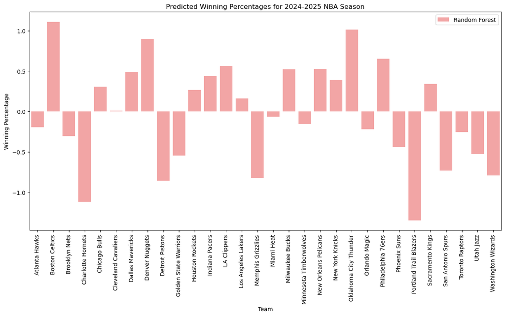

```python
# Plotting future predictions
plt.figure(figsize=(15, 7))

sns.barplot(x='Team', y='RF_WinPCT_2024_2025', data=future_predictions, color='red', alpha=0.4, label='Random Forest')


plt.title('Predicted Winning Percentages for 2024-2025 NBA Season')
plt.xticks(rotation=90)
plt.ylabel('Winning Percentage')
plt.legend()
plt.show()
```

##### Model Performance Comparison:

This model looks similar to the win percentages for the teams this season. There will still be the top 3 teams and bottom 4 teams in comparison to this year. Compared to the other models, this had the largest room for error and is more conservative. Therefore there could actually be less change than what will actually happen.

## Interpretation: Insight & Policy Decision

#### Further Research:

- Incorporate More Seasons: Including more data could improve the model's robustness.
- Advanced Metrics: Use player-level efficiency metrics to enhance the model.
- Roster Changes: See how off-season player movement affects a team

### Conclusion:

Additionally, we created a linear regression model with a high r^2 and low error values, that could be used to calculate further predictions outside of the upcoming 2024-2025 season.